# Compito di Statistica

Scrivere in stampatello

| COGNOME | $\LARGE\square$ | $\LARGE\square$ | $\LARGE\square$ | $\LARGE\square$ | $\LARGE\square$ | $\LARGE\square$ | $\LARGE\square$ | $\LARGE\square$ | $\LARGE\square$ | $\LARGE\square$ | $\LARGE\square$ | $\LARGE\square$ | $\LARGE\square$ | $\LARGE\square$ | $\LARGE\square$ | $\LARGE\square$ | $\LARGE\square$ | $\LARGE\square$ | $\LARGE\square$ | $\LARGE\square$ |
| --- | --- | --- | --- | --- | --- | --- | --- | --- | --- | --- | --- | --- | --- | --- | --- | --- | --- | --- | --- | --- |
| NOME | $\LARGE\square$ | $\LARGE\square$ | $\LARGE\square$ | $\LARGE\square$ | $\LARGE\square$ | $\LARGE\square$ | $\LARGE\square$ | $\LARGE\square$ | $\LARGE\square$ | $\LARGE\square$ | $\LARGE\square$ | $\LARGE\square$ | $\LARGE\square$ | $\LARGE\square$ | $\LARGE\square$ | $\LARGE\square$ | $\LARGE\square$ | $\LARGE\square$ | $\LARGE\square$ | $\LARGE\square$ |
| Matricola | $\LARGE\square$ | $\LARGE\square$ | $\LARGE\square$ | $\LARGE\square$ | $\LARGE\square$ | $\LARGE\square$ | $\LARGE\square$ | $\LARGE\square$ | $\LARGE\square$ | $\LARGE\square$ | $\LARGE\square$ | $\LARGE\square$ | $\LARGE\square$ | $\LARGE\square$ | $\LARGE\square$ | $\LARGE\square$ | $\LARGE\square$ | $\LARGE\square$ | $\LARGE\square$ | $\LARGE\square$ |
| CDL | $\LARGE\square$ | $\LARGE\square$ | $\LARGE\square$ | $\LARGE\square$ | $\LARGE\square$ |  |  |  |  |  |  |  |  |  |  |  |  |  |  |  |

### Esercizio 1

Su un campione di $220$ imprese della provincia di Milano è stato rilevato il bilancio, espresso in migliaia di euro, del 2020. Qui di seguito i dati raccolti in classi e le densità di frequenza percentuale.

| $[\text{x}_j,$ | $\text{x}_{j+1})$ | $h_j$ |
| --- | --- | --- |
| -10 | -5 | 0.9091 |
| -5 | 0 | 3.4545 |
| 0 | 2 | 26.1364 |
| 2 | 4 | 8.6364 |
| 4 | 6 | 4.3182 |

1.a (**Punti 14 su 104 (4.04 su 30)**) Calcolare il valore approssimato della mediana.

| $[\text{x}_j,$ | $\text{x}_{j+1})$ | $n_j$ | $f_j$ | $b_j$ | $h_j$ | $F_j$ |
| --- | --- | --- | --- | --- | --- | --- |
| -10 | -5 | 10 | 0.0455 | 5 | 0.9091 | 0.0455 |
| -5 | 0 | 38 | 0.1727 | 5 | 3.4545 | 0.2182 |
| 0 | 2 | 115 | 0.5227 | 2 | 26.1364 | 0.7409 |
| 2 | 4 | 38 | 0.1727 | 2 | 8.6364 | 0.9136 |
| 4 | 6 | 19 | 0.0864 | 2 | 4.3182 | 1.0000 |
|  |  | 220 | 1.0000 | 16 |  |  |

$$\begin{eqnarray*}
p &=& 0.5, \text{essendo }F_{3}=0.7409 >0.5 \Rightarrow
j_{0.5}=3\\
x_{0.5} &=& x_{\text{inf};3} + \frac{ {0.5} - F_{2}} {f_{3}}
\cdot b_{3} \\
&=& 0 + \frac {{0.5} - 0.2182} {0.5227} \cdot 2
\\
&=& 1.0783
\end{eqnarray*}$$

1.b (**Punti 3 su 104 (0.87 su 30)**) Quante aziende hanno un bilancio compreso tra $-1$ e il 75-esimo percentile?

$$\begin{eqnarray*}
F(x_{0.75}) &=& 0.75\\
F(-1) &=& f_1+4h_2/100\\
&=& 0.0455+4\times 3.4545/100\\
&=& 0.1836\\
\%(-1<X<x_{0.75}) &=& (F(x_{0.75})-F(x_{-1}))\times
100\\
&=& (0.5664)\times 100 \%\\
\#(-1<X<x_{0.75}) &=& n\%(-1<X<x_{0.75})/100 \\
&=& 124.6
\end{eqnarray*}$$

$$\#(-1<X<x_{0.75})=n\%(-1<X<x_{0.75})/100=n/100(75-F(-1))$$

1.c (**Punti 2 su 104 (0.58 su 30)**) Che relazione dobbiamo attenderci tra media, mediana e moda?

1.d (**Punti 2 su 104 (0.58 su 30)**) Sapendo che $\sigma_X=2.8196$ la Standard Deviation di $X$ e posto $y_i=-x_i, \forall i$, quanto varrà $\sigma_Y$, la standard deviation dei dati così trasformati?

### Esercizio 2

Siano $X$ e $Y$ due variabili casuali che rappresentano rispettivamente il tempo di manutenzione per due tipi di macchinari diversi in un’azienda manifatturiera. Si sa che $X\sim N(15,1.5)$ e $Y\sim N(12,1.5)$. L’azienda ha definito due eventi $A=\{X< 14\}$ e $B=\{Y<13\}$ Si suppone inoltre che i tempi di manutenzione dei due macchinari siano indipendenti tra loro.

2.a (**Punti 14 su 104 (4.04 su 30)**) Calcola la probabilità che almeno uno dei due eventi sia vero ($A \cup B$).

$$\begin{eqnarray*}
P(X < 14)
&=& P\left( \frac {X - \mu_X}{\sigma_X} < \frac {14 -
15}{\sqrt{1.5}} \right) \\
&=& P\left( Z < -0.82\right) \\
&=& 1-\Phi( 0.82 ) \\ &=& 0.2061
\end{eqnarray*}$$

2.b (**Punti 3 su 104 (0.87 su 30)**) Quando il tempo di manutenzione del macchinario $X$ è inferiore a 14 ore ($A=\{X< 14\}$), la perdita economica dell’azienda è di €100. Mentre quando è superiore a 14 la perdita è di 500€.

Calcolare la probabilità che l’azienda abbia una perdita economica totale superiore ai 600€.

2.c (**Punti 2 su 104 (0.58 su 30)**) Siano $Z_1\sim N(0,1)$, $Z_2\sim N(0,1)$, $Z_3\sim N(0,1)$, tre VC normali standard indipendenti. Come si distribuisce
$$Y=Z_1^2+Z_2^2+Z_3^3~~~?$$

2.d (**Punti 2 su 104 (0.58 su 30)**) Se $A$ e $B$ sono due eventi tali che $A\cap B\ne\emptyset$, $A$ e $B$ sono indipendenti? (scegliere tra *sempre, mai, dipende* e motivare la risposta)

### Esercizio 3

3.a (**Punti 14 su 104 (4.04 su 30)**) Un’urna contiene 4 palline numerate con $\fbox{0}$, $\fbox{3}$, $\fbox{4}$ e $\fbox{6}$. Si estrae 100 volte con reinserimento. Qual è la probabilità che la somme delle 100 estrazioni sia maggiore di 310?

$$\begin{eqnarray*}
\mu &=& \frac 1{ 4 }( 0 + 3 + 4 + 6 )= 3.25 \\
\sigma^2 &=& \frac 1{ 4 }( 0 ^2+ 3 ^2+ 4 ^2+ 6 ^2 )-( 3.25 )^2=
4.688
\end{eqnarray*}$$
**Teorema del Limite Centrale (somma VC qualunque)**

Siano $X_1$,…,$X_n$, $n=100$ VC IID, tc $E(X_i)=\mu=3.25$ e $V(X_i)=\sigma^2=4.688,\forall i$, posto:
$$S_n = X_1 + ... + X_n$$
allora:
$$\begin{eqnarray*}
S_n & \mathop{\sim}\limits_{a}& N(n\mu,n\sigma^2) \\
&\sim & N(100\cdot3.25,100\cdot4.688) \\
&\sim & N(325,468.8)
\end{eqnarray*}$$

$$\begin{eqnarray*}
P(S_n > 310)
&=& P\left( \frac {S_n - n\mu}{\sqrt{n\sigma^2}} > \frac
{310 - 325}{\sqrt{468.75}} \right) \\
&=& P\left( Z > -0.69\right) \\ &=&
1-P(Z< -0.69 )\\
&=& 1-(1-\Phi( 0.69 )) \\ &=& 0.7549
\end{eqnarray*}$$

### Esercizio 4

4.a (**Punti 3 su 104 (0.87 su 30)**) Sia $\hat \mu$ lo stimatore di massima verosimiglianza di $\mu$ del modello Normale.
$$\begin{eqnarray*}
\hat\mu &=& \frac 1n\sum_{i=1}^nx_i\\
\end{eqnarray*}$$
Dimostrare le consistenza di $\hat\mu$ in almeno tre passaggi.

4.b (**Punti 2 su 104 (0.58 su 30)**) Siano $h_1$ e $h_2$ due stimatori per $\theta$, cosa significa dire che $h_1$ è più efficiente di $h_2$?

4.c (**Punti 3 su 104 (0.87 su 30)**) Definire la significatività e la potenza di un test statistico.

4.d (**Punti 3 su 104 (0.87 su 30)**) Se in un test statistico il $p_\text{value}>0.1$ possiamo rifiutare $H_0$?

### Esercizio 5

5.a (**Punti 14 su 104 (4.04 su 30)**) In uno studio comparativo tra i redditi, nel comune $A$ si è rilevato il reddito di 12 individui e si è osservata una media pari 27 mila euro con una standard deviation pari a 4.2 mila euro , mentre nel comune $B$ si è rilevato il reddito di 25 individui e si è osservata una media pari 24 mila euro con una standard deviation pari a 3.1 mila euro. Sotto ipotesi di eterogeneità, testare al livello di **significatività del’5% e dell’1%** l’ipotesi che il reddito medio sia uguale nei due comuni, contro l’alternativa che sia maggiore nel comune $A$.

$\fbox{A}$ FORMULAZIONE DELLE IPOTESI

$$\begin{cases}
H_0:\mu_\text{1} = \mu_\text{ 2}\text{}\\
H_1:\mu_\text{1} > \mu_\text{ 2}\text{}
\end{cases}$$

$\fbox{B}$ SCELTA E CALCOLO STATISTICA-TEST, $T$

L’ipotesi è di eterogeneità e quindi calcoliamo:
$$S^2_\text{1}=\frac{n_\text{1}}{n_\text{1}-1}\hat\sigma^2_\text{1}=\frac{12}{12-1}4.2^2=19.2436
\qquad
S^2_\text{2}=\frac{n_\text{2}}{n_\text{2}-1}\hat\sigma^2_\text{2}=\frac{25}{25-1}3.1^2=10.0104$$

$$\begin{eqnarray*}
\frac{\hat\mu_\text{1} - \hat\mu_\text{2}}
{\sqrt{\frac {S^2_\text{1}}{n_\text{1}}+\frac
{S^2_\text{2}}{n_\text{2}}}}&\sim&t_{n_\text{1}+n_\text{2}-2}\\
t_{\text{obs}}
&=& \frac{ (27- 24)}
{\sqrt{\frac{19.2436}{12}+\frac{10.0104}{25}}}
= 2.1192\, .
\end{eqnarray*}$$

$\fbox{C}$ DECISIONE

Dalle tavole si ha $t_{(12+25-2);\, 0.01} = 2.4377$.
$$t_{\text{obs}} = 2.1192
< t_{35;\, 0.01} = 2.4377$$

**Graficamente**

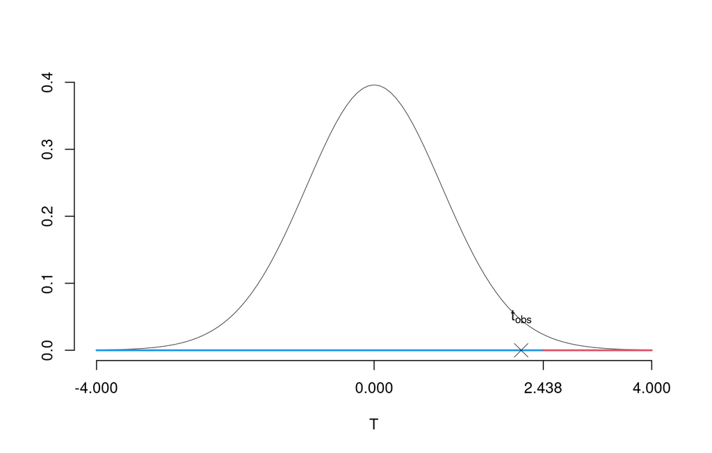

Il $p_{\text{value}}$ è
$$P(T_{n1+n2-2}>t_{\text{obs}})=P(T_{n1+n2-2}>
2.119 )= 0.02062$$

### Esercizio 6

In uno studio sull’efficacia del marketing sul web si sono analizzate 50 aziende sulle quali è stato misurata l’incremento percentuale annuo medio di investimento in marketing web ($X$) la l’incremento percentuale medio di utile ($Y$). Si osservano le seguenti statistiche, $\sum_{i=1}^{50}x_i=40.041$, $\sum_{i=1}^{50}y_i=116.137$, $\sum_{i=1}^{50}x_i^2=41.5873$, $\sum_{i=1}^{50}y_i^2=308.6013$ e $\sum_{i=1}^{50}x_iy_i=110.684$.

6.a (**Punti 14 su 104 (4.04 su 30)**) Stimare il modello di regressione dove $Y$ viene spiegata da $X$ e interpretare i coefficienti $\hat\beta_0$ e $\hat\beta_1$

$$\begin{eqnarray*}
\bar x &=&\frac 1 n\sum_{i=1}^n x_i = \frac {1}{50} 40.041=
0.8008\\
\bar y &=&\frac 1 n\sum_{i=1}^n y_i = \frac {1}{50} 116.137=
2.3227\\
\hat\sigma_X^2&=&\frac 1 n\sum_{i=1}^n x_i^2-\bar x^2=\frac
{1}{50} 41.5873 -0.8008^2=0.1904\\
\hat\sigma_Y^2&=&\frac 1 n\sum_{i=1}^n y_i^2-\bar y^2=\frac
{1}{50} 308.6013 -2.3227^2=0.7769\\
\text{cov}(X,Y)&=&\frac 1 n\sum_{i=1}^n x_i~y_i-\bar x\bar
y=\frac {1}{50} 110.684-0.8008\cdot2.3227=0.3536\\
\hat\beta_1 &=& \frac{\text{cov}(X,Y)}{\hat\sigma_X^2} \\
&=& \frac{0.3536}{0.1904} = 1.8567\\
\hat\beta_0 &=& \bar y - \hat\beta_1 \bar x\\
&=& 2.3227-1.8567\times 0.8008=0.8358
\end{eqnarray*}$$

6.b (**Punti 3 su 104 (0.87 su 30)**) Scrivere la scomposizione della varianza e calcolarla per questo caso.

$$\begin{eqnarray*}
TSS &=& n\hat\sigma^2_Y\\
&=& 50 \times 0.7769 \\
&=& 38.85 \\
ESS &=& R^2\cdot TSS\\
&=& 0.845 \cdot 38.85 \\
&=& 32.83 \\
RSS &=& (1-R^2)\cdot TSS\\
&=& (1- 0.845 )\cdot 38.85 \\
&=& 6.02 \\
TSS &=& RSS+TSS \\ 38.85 &=& 32.83 + 6.02
\end{eqnarray*}$$

6.c (**Punti 2 su 104 (0.58 su 30)**) Perché una previsione per $x=0.15$ è più affidabile di una per $x=50$?

6.d (**Punti 2 su 104 (0.58 su 30)**) Interpretare il diagramma dei residui.

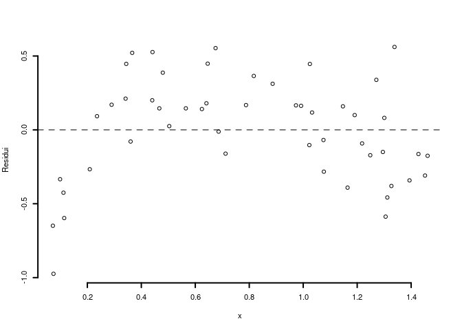

6.e (**Punti 2 su 104 (0.58 su 30)**) Cosa significa dire che $r$ è un numero puro?